# Reproducible Research - Peer Assesment

Ade Ososami

July 10, 2016

# Introduction

It is now possible to collect a large amount of data about personal movement using activity monitoring devices such as a Fitbit, Nike Fuelband, or Jawbone Up. These type of devices are part of the quantified self movement a group of enthusiasts who take measurements about themselves regularly to improve their health, to find patterns in their behavior, or because they are tech geeks. But these data remain under-utilized both because the raw data are hard to obtain and there is a lack of statistical methods and software for processing and interpreting the data.

This assignment makes use of data from a personal activity monitoring device. This device collects data at 5 minute intervals through out the day. The data consists of two months of data from an anonymous individual collected during the months of October and November, 2012 and include the number of steps taken in 5 minute intervals each day.

The data for this assignment can be downloaded from the repository.

Dataset: Activity monitoring data [52K]

### The variables included in this dataset are:

**steps**: Number of steps taking in a 5-minute interval (missing values are coded as NA)

**date**: The date on which the measurement was taken in YYYY-MM-DD format

**interval**: Identifier for the 5-minute interval in which measurement was taken

The dataset is stored in a comma-separated-value (CSV) file and there are a total of 17,568 observations in this dataset.

## Objectives

1.Code for reading in the dataset and/or processing the data

2.Histogram of the total number of steps taken each day

3.Mean and median number of steps taken each day

4.Time series plot of the average number of steps taken

5.The 5-minute interval that, on average, contains the maximum number of steps

6.Code to describe and show a strategy for imputing missing data

7.Histogram of the total number of steps taken each day after missing values are imputed

8.Panel plot comparing the average number of steps taken per 5-minute interval across weekdays and weekends

### 1.Code for reading in the dataset and/or processing the data

In order to manipulate and effectively analyse the data we are going to need a couple of packages.

```r
require(lubridate)
require(dplyr)
```

The dataset has already been downloaded,unzipped and saved in the same directory as this project. Now we can read the dataset into R.

```r
act<-read.csv("activity.csv")
```

We can look at the file briefly to get an overview of the data.

```r
str(act)
```

```
## 'data.frame':    17568 obs. of  3 variables:
##  $ steps   : int  NA NA NA NA NA NA NA NA NA NA ...
##  $ date    : Factor w/ 61 levels "2012-10-01","2012-10-02",..: 1 1 1 1 1 1 1 1 1 1 ...
##  $ interval: int  0 5 10 15 20 25 30 35 40 45 ...
```

We can see the date variable isn’t in the right format, and NA values exist within the data. We need to note this as we go further into our analysis.

We can now convert the date variable to a more suitable format for analysis

```r
act$date<-ymd(act$date)
str(act)
```

```
## 'data.frame':    17568 obs. of  3 variables:
##  $ steps   : int  NA NA NA NA NA NA NA NA NA NA ...
##  $ date    : Date, format: "2012-10-01" "2012-10-01" ...
##  $ interval: int  0 5 10 15 20 25 30 35 40 45 ...
```

We can now see the date variable has been converted to a **date** variable. We are done with reading/processing the data and can begin analysing it.

### 2.Histogram of the total number of steps taken each day

Our aim, is to collate the number of steps for each day. The code below aggregates the steps by date, and creates a histogram of the steps.

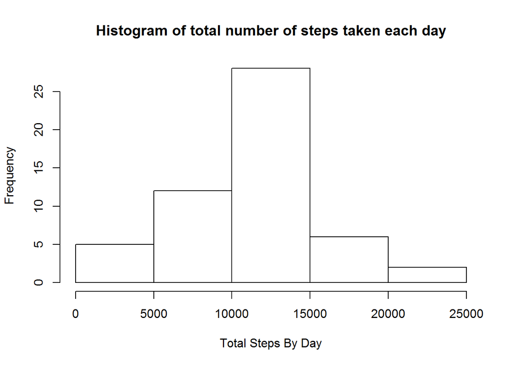

```r
tot.steps.day<-aggregate(steps~date, data =act,sum, na.rm=T)
hist(tot.steps.day$steps,main="Histogram of total number of steps taken each day",xlab="Total Steps By Day")
```

### 3.Mean and median number of steps taken each day

We will now like to see the mean and median of steps taken each day.

```r
mean.steps<-mean(tot.steps.day$steps)
median.steps<-median(tot.steps.day$steps)
sumr<-data.frame(mean=mean.steps,median=median.steps)
sumr
```

```
##       mean median
## 1 10766.19  10765
```

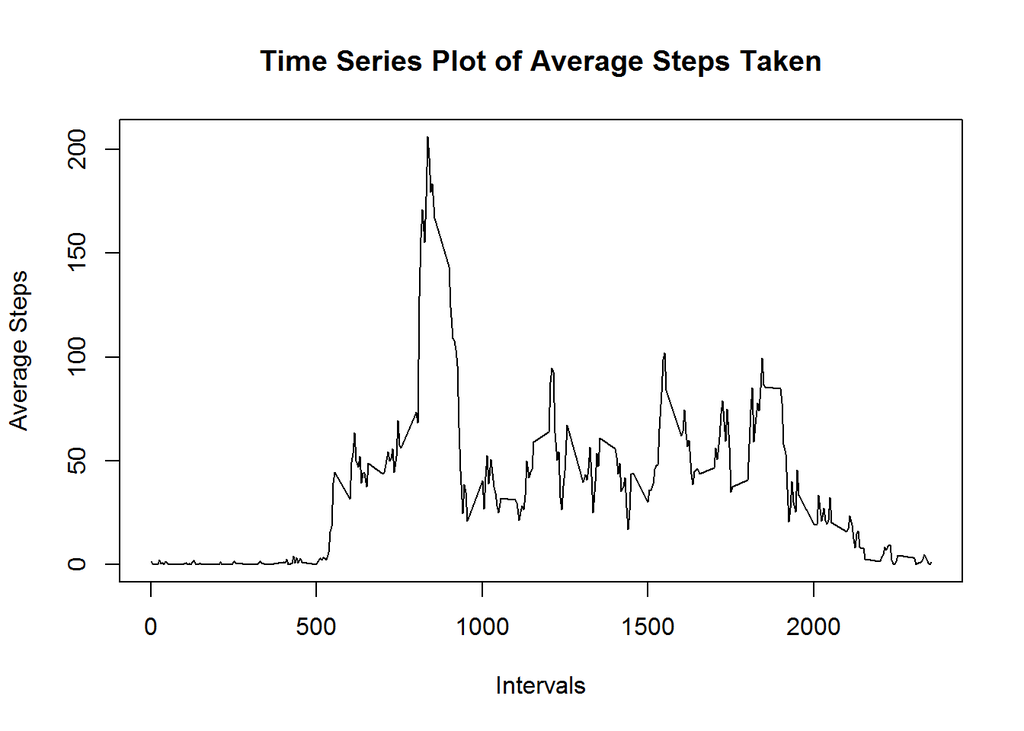

```r
average.steps.inter<-aggregate(steps~interval, data=act,mean, na.rm=T)
plot(average.steps.inter$interval,average.steps.inter$steps,type="l",xlab="Intervals",
     ylab="Average Steps",main="Time Series Plot of Average Steps Taken")
```

```r
max.average.steps.inter<-average.steps.inter[order(average.steps.inter$steps, decreasing=T),]
max.num<-max.average.steps.inter[1,1]
```

### 6.Code to describe and show a strategy for imputing missing data

As we noticed during the preparation stage, there are a few NA values.

```r
na.perc<-mean(is.na(act$steps))*100
na.perc
```

```
## [1] 13.11475
```

```r
act.imp<- act %>%
        group_by(interval) %>%
        mutate(steps = ifelse(is.na(steps), mean(steps, na.rm=TRUE), steps))
summary(act.imp)
```

```
##      steps             date               interval
##  Min.   :  0.00   Min.   :2012-10-01   Min.   :   0.0
##  1st Qu.:  0.00   1st Qu.:2012-10-16   1st Qu.: 588.8
##  Median :  0.00   Median :2012-10-31   Median :1177.5
##  Mean   : 37.38   Mean   :2012-10-31   Mean   :1177.5
##  3rd Qu.: 27.00   3rd Qu.:2012-11-15   3rd Qu.:1766.2
##  Max.   :806.00   Max.   :2012-11-30   Max.   :2355.0
```

We can see there are no longer NA values within the data set.

### 7.Histogram of the total number of steps taken each day after missing values are imputed

Now we can look at the data set with no NA values to compare if it has made any significant changes.

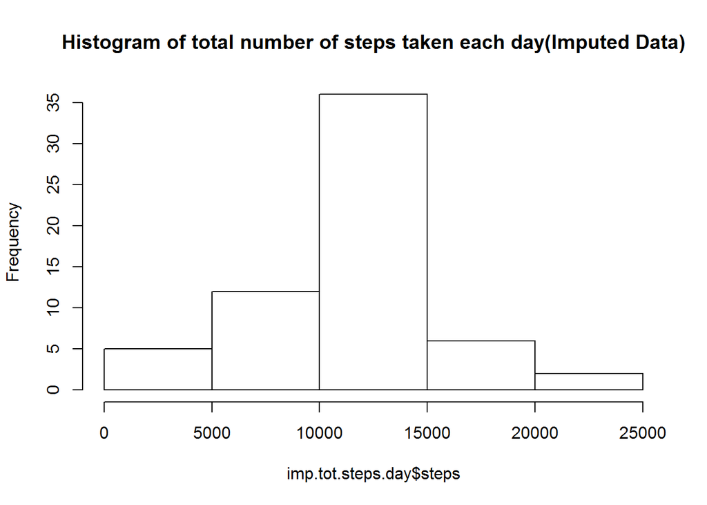

```r
imp.tot.steps.day<-aggregate(steps~date, data =act.imp,sum, na.rm=T)

hist(imp.tot.steps.day$steps,main="Histogram of total number of steps taken each day(Imputed Data)")
```

```r
imp.mean.steps<-mean(imp.tot.steps.day$steps)
imp.median.steps<-median(imp.tot.steps.day$steps)
imp.sumr<-data.frame(mean=mean.steps,median=median.steps)
imp.sumr
```

```
##       mean median
## 1 10766.19  10765
```

### 8.Panel plot comparing the average number of steps taken per 5-minute interval across weekdays and weekends

We have now processed the data, and replaced the NA values with values. We can then proceed in comparing the steps taken per 5-minute interval across weekdays and weekends.

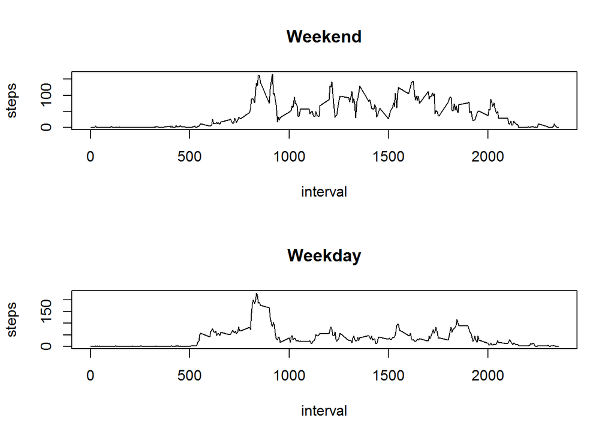

```r
act.imp$day<-weekdays(act.imp$date)
act.imp$day.type<-0
act.imp$day.type<-ifelse(act.imp$day %in% c("Saturday","Sunday"),"Weekend","Weekday")
act.imp$day.type<-factor(act.imp$day.type)

par(mfrow = c(2, 1))
for (type in c("Weekend", "Weekday")) {
        steps.type <- aggregate(steps ~ interval, data = act.imp, subset = act.imp$day.type ==
                                        type, FUN = mean)
        plot(steps.type, type = "l", main = type)
}
```